# 2-18 Blog, The Olympics

Author

Ben Lee

```r
## install.packages("tidyverse")
## install.packages("gt")
## install.packages("ggTimeSeries")
## install.packages("ggplot2")
```

## Introduction

the blog post the data was gathered from can be found at the following link: https://github.com/rfordatascience/tidytuesday/blob/main/data/2026/2026-02-10/readme.md

```r
library(tidyverse)
library(gt)

# Load the events data

dataset_url <- "https://raw.githubusercontent.com/chendaniely/olympics-2026/refs/heads/main/data/final/olympics/olympics_events.csv"
df <- readr::read_csv(dataset_url)
# Create schedule summary
schedule <- df |>
  group_by(date, discipline_name) |>
  summarize(
    total_events = n(),
    medal_events = sum(is_medal_event),
    .groups = "drop"
  ) |>
  arrange(date, discipline_name)

cat("Schedule shape:", nrow(schedule), "x", ncol(schedule), "\n")
```

```
Schedule shape: 229 x 4
```

```r
cat("\nFirst 20 rows:\n")
```

```
First 20 rows:
```

```r
print(head(schedule, 20))
```

```
# A tibble: 20 × 4
   date       discipline_name      total_events medal_events
   <date>     <chr>                       <int>        <int>
 1 2026-02-04 Alpine Skiing                   3            0
 2 2026-02-04 Curling                        14            0
 3 2026-02-04 Ice Hockey                      4            0
 4 2026-02-04 Luge                            6            0
 5 2026-02-04 Ski Jumping                     2            0
 6 2026-02-04 Snowboard                       3            0
 7 2026-02-05 Alpine Skiing                   5            0
 8 2026-02-05 Curling                        21            0
 9 2026-02-05 Figure Skating                  3            0
10 2026-02-05 Ice Hockey                      6            0
11 2026-02-05 Luge                            8            0
12 2026-02-05 Ski Jumping                     3            0
13 2026-02-05 Snowboard                       3            0
14 2026-02-06 Alpine Skiing                   6            1
15 2026-02-06 Cross-Country Skiing            1            1
16 2026-02-06 Curling                        27            0
17 2026-02-06 Figure Skating                  5            0
18 2026-02-06 Freestyle Skiing                4            0
19 2026-02-06 Ice Hockey                     10            0
20 2026-02-06 Luge                           10            0
```

```r
# Convert date column to Date type
schedule <- schedule |>
  mutate(date = as.Date(date))

cat("\nUpdated column types:\n")
```

```
Updated column types:
```

```r
print(str(schedule))
```

```
tibble [229 × 4] (S3: tbl_df/tbl/data.frame)
 $ date           : Date[1:229], format: "2026-02-04" "2026-02-04" ...
 $ discipline_name: chr [1:229] "Alpine Skiing" "Curling" "Ice Hockey" "Luge" ...
 $ total_events   : int [1:229] 3 14 4 6 2 3 5 21 3 6 ...
 $ medal_events   : int [1:229] 0 0 0 0 0 0 0 0 0 0 ...
NULL
```

```r
cat("\nFirst few rows:\n")
```

```
First few rows:
```

```r
print(head(schedule, 10))
```

```
# A tibble: 10 × 4
   date       discipline_name total_events medal_events
   <date>     <chr>                  <int>        <int>
 1 2026-02-04 Alpine Skiing              3            0
 2 2026-02-04 Curling                   14            0
 3 2026-02-04 Ice Hockey                 4            0
 4 2026-02-04 Luge                       6            0
 5 2026-02-04 Ski Jumping                2            0
 6 2026-02-04 Snowboard                  3            0
 7 2026-02-05 Alpine Skiing              5            0
 8 2026-02-05 Curling                   21            0
 9 2026-02-05 Figure Skating             3            0
10 2026-02-05 Ice Hockey                 6            0
```

```r
# Pivot the schedule to have disciplines as rows and dates as columns
schedule_pivot <- schedule |>
  select(date, discipline_name, total_events) |>
  pivot_wider(
    names_from = date,
    values_from = total_events,
    id_cols = discipline_name
  ) |>
  arrange(discipline_name)

# Create the table
gt_table <- schedule_pivot |>
  gt() |>
  tab_header(
    title = "Olympics 2026 Event Schedule",
    subtitle = "Total events per sport by date"
  ) |>
  cols_label(
    discipline_name = "Sport"
  )

gt_table
```

Olympics 2026 Event Schedule

Total events per sport by date

| Sport | 2026-02-04 | 2026-02-05 | 2026-02-06 | 2026-02-07 | 2026-02-08 | 2026-02-09 | 2026-02-10 | 2026-02-11 | 2026-02-12 | 2026-02-13 | 2026-02-14 | 2026-02-15 | 2026-02-16 | 2026-02-17 | 2026-02-18 | 2026-02-19 | 2026-02-20 | 2026-02-21 | 2026-02-22 |
| --- | --- | --- | --- | --- | --- | --- | --- | --- | --- | --- | --- | --- | --- | --- | --- | --- | --- | --- | --- |
| Alpine Skiing | 3 | 5 | 6 | 5 | 6 | 6 | 6 | 4 | 2 | 3 | 4 | 6 | 4 | 4 | 2 | 2 | NA | NA | NA |
| Biathlon | NA | NA | NA | 1 | 1 | 2 | 2 | 2 | 2 | 2 | 4 | 3 | 3 | 2 | 2 | 2 | 2 | 2 | 1 |
| Bobsleigh | NA | NA | NA | NA | NA | NA | NA | 4 | 8 | 12 | 10 | 10 | 10 | 12 | 12 | 12 | 12 | 10 | 6 |
| Cross-Country Skiing | NA | NA | 1 | 2 | 2 | 9 | 8 | 9 | 2 | 3 | 3 | 2 | 1 | 4 | 4 | 4 | 1 | 2 | 2 |
| Curling | 14 | 21 | 27 | 27 | 26 | 18 | 12 | 17 | 27 | 34 | 34 | 33 | 33 | 33 | 32 | 24 | 15 | 6 | 3 |
| Figure Skating | NA | 3 | 5 | 8 | 6 | 5 | 3 | 2 | 2 | 1 | 2 | 2 | 3 | 2 | 2 | 1 | 1 | NA | NA |
| Freestyle Skiing | NA | NA | 4 | 4 | 7 | 8 | 11 | 11 | 6 | 12 | 18 | 21 | 19 | 12 | 15 | 17 | 26 | 20 | 11 |
| Ice Hockey | 4 | 6 | 10 | 8 | 10 | 10 | 10 | 10 | 12 | 16 | 16 | 12 | 10 | 10 | 10 | 8 | 5 | 4 | 2 |
| Luge | 6 | 8 | 10 | 14 | 18 | 20 | 16 | 11 | 5 | 1 | NA | NA | NA | NA | NA | NA | NA | NA | NA |
| Nordic Combined | NA | NA | NA | NA | 1 | 2 | 5 | 4 | 4 | 1 | 2 | 2 | 5 | 5 | 7 | 4 | 3 | NA | NA |
| Short Track Speed Skating | NA | NA | NA | NA | NA | 6 | 6 | 14 | 8 | 14 | 6 | 12 | 6 | 12 | 6 | 12 | 6 | 6 | NA |
| Skeleton | NA | NA | NA | NA | 4 | 8 | 12 | 10 | 10 | 8 | 7 | 3 | 1 | NA | NA | NA | NA | NA | NA |
| Ski Jumping | 2 | 3 | 6 | 6 | 8 | 8 | 6 | 5 | 3 | 7 | 9 | 12 | 8 | 4 | NA | NA | NA | NA | NA |
| Ski Mountaineering | NA | NA | NA | NA | NA | NA | NA | NA | NA | NA | NA | NA | NA | NA | 6 | 6 | 7 | 1 | 1 |
| Snowboard | 3 | 3 | 6 | 20 | 23 | 20 | 7 | 14 | 24 | 20 | 14 | 8 | 11 | 10 | 6 | 3 | NA | NA | NA |
| Speed Skating | NA | NA | 1 | 2 | 3 | 2 | 2 | 2 | 3 | 4 | 5 | 4 | 12 | 10 | 11 | 2 | 6 | 5 | 4 |

## Primary Visualizations

As mentioned in my previous blog post, I have been reviewing my notes from a previous stats class and try to connect information from said class to this one. I noticed that dates were included in this dataset and wanted to apply a package to the Olympic data. As shown in the following image, it appears that the total number of events peak on the weekends and are lowest during the middle of the week. It also shows that the events tend to peak in the middle of the Olympics with the two lowest days being the first and final day of the Winter Olympics.

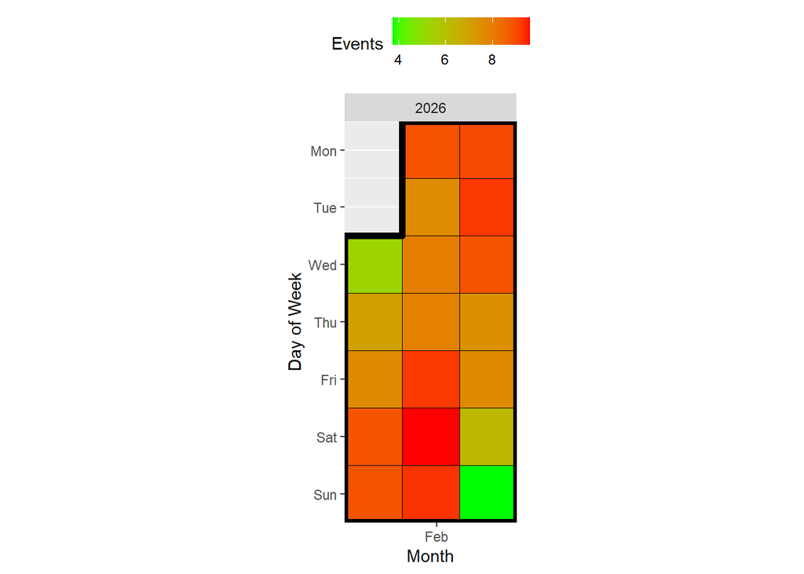

```r
library(lubridate)
library(ggTimeSeries)
library(dplyr)
library(ggplot2)

schedule |>
  group_by(date) |>
  summarise(avg_daily_events = mean(total_events, na.rm=TRUE)) |>
  ungroup() |>
  ggplot_calendar_heatmap("date",
                        "avg_daily_events",
                        ) +
  theme(legend.position = "top") +
  scale_fill_continuous(low = 'green', high = 'red') +
  labs(y = "Day of Week", y = "Month", fill = "Events")
```

After noticing this trend, I decided to revisit the initial data and see if this is true for all sports or if these trends were being influenced by other sports. To depict my findings I used a similar image but facet wrapped the graphs to each sport resulting in the following image.

```
`summarise()` has regrouped the output.
ℹ Summaries were computed grouped by date and discipline_name.
ℹ Output is grouped by date.
ℹ Use `summarise(.groups = "drop_last")` to silence this message.
ℹ Use `summarise(.by = c(date, discipline_name))` for per-operation grouping
  (`?dplyr::dplyr_by`) instead.
```

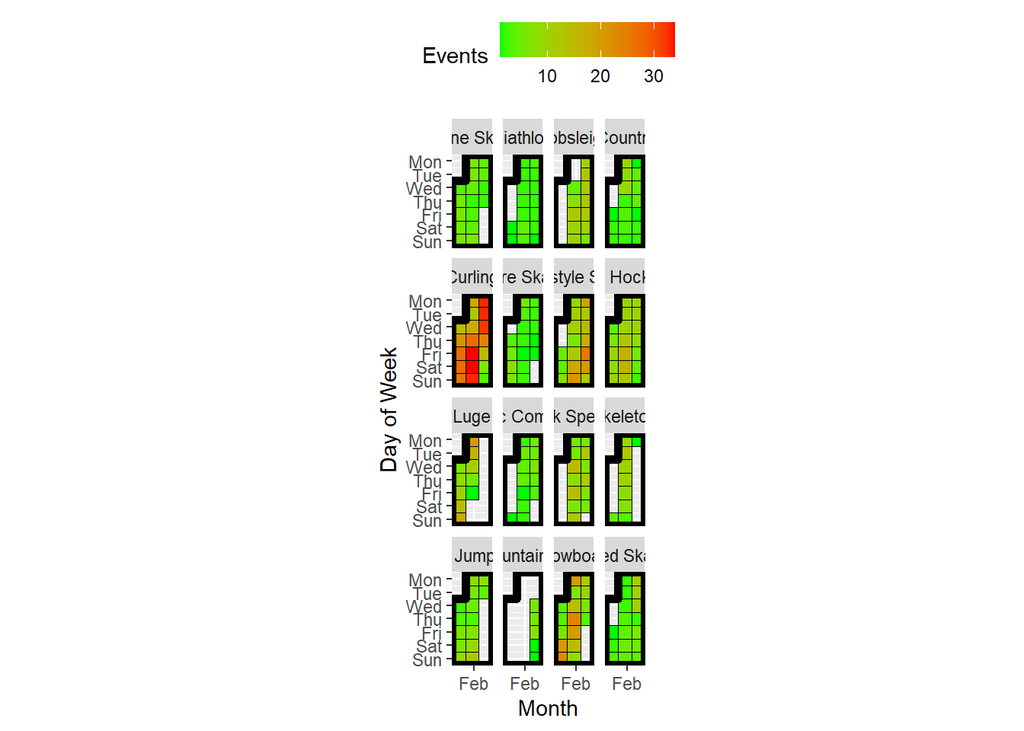

```r
schedule |>
  group_by(date, discipline_name) |>
  summarise(avg_daily_events = mean(total_events, na.rm=TRUE)) |>
  ungroup() |>
  ggplot_calendar_heatmap("date",
                        "avg_daily_events",
                        ) +
  facet_wrap(~discipline_name) +
  theme(legend.position = "top") +
  scale_fill_continuous(low = 'green', high = 'red') +
  labs(y = "Day of Week", y = "Month", fill = "Events")
```

It may be difficult to see but curling seems to have largely influenced the data as it has the most extreme values. Once I saw this it reminded me of a principle we recently learned in my stats class related to the variability of data. In this case, curling influenced the perceived number of events for each day of the Olympics. Although the graph is very cool it does not properly represent the data we collected. To properly show the variability of the data the following graph was created.

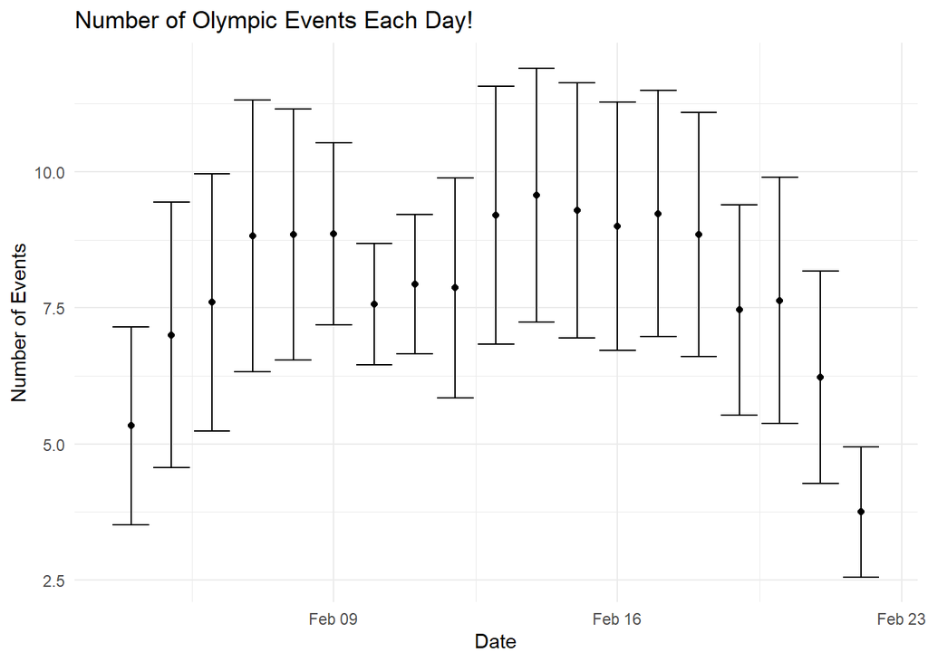

```r
schedule_clean <- schedule |>
  filter(!is.na(total_events)) |>
  group_by(date) |>
  summarise(mean_events = mean(total_events),
            se = sd(total_events)/ sqrt(n())) |>
  mutate(se_ub = mean_events + se,
         se_lb = mean_events - se)

ggplot(data = schedule_clean, aes(x = date, y = mean_events)) +
  geom_errorbar(aes(ymax = se_ub, ymin = se_lb)) +
  geom_point() +
  theme_minimal() +
labs(x = "Date", y = "Number of Events",
       title = "Number of Olympic Events Each Day!")
```

With this graph we are able to see the average number of events each day of the Winter Olympics. We can also see the variability in events for each of the days. However, we cannot see each event individually.

```
Ignoring unknown labels:
• legend : "Sport"
```

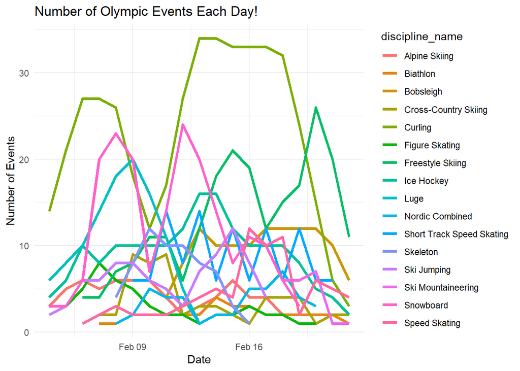

```r
schedule |>
  filter(!is.na(total_events)) |>
  group_by(discipline_name) |>
  ggplot(aes(x = date, y = total_events, color = discipline_name))+
  geom_line(linewidth = 1.25) +
  scale_color_discrete()  +
  theme_minimal() +
  labs(x = "Date", y = "Number of Events",
       title = "Number of Olympic Events Each Day!",
       legend = "Sport")
```

## Conclusion

This final graph allows us to see the trend of each Winter Olympic sport and the number of events it has for each day. It also shows the variability of each individual event without relying on summary statistics. Although the previous graphs partially answer our initial question of how are the events distributed throughout the Olympics, they do not tell the entire story. With the final graph we can correctly interperate the data.